# New data-cleaning tools in R

Laurie Samuels

Fri 01 Dec 2017, 14:11

# 1 Setup

```r
### LOADING LIBRARIES ###
library(Hmisc)
library(rms)
library(magrittr)
library(dplyr)
library(ggplot2)
library(gridExtra)
library(lubridate)
library(knitr)
library(stringr)
library(dataMaid)
library(validate)
library(janitor)
library(assertr)

knitrSet(
    lang='markdown',
    h=4.5,
    messages= 'console'
)
mSpecs <- markupSpecs$html   # markupSpecs is in Hmisc
cap  <- mSpecs$cap           # function to output html caption
lcap <- mSpecs$lcap          # for continuation for long caption
# These last 2 functions are used by the putHfig function in Hmisc

#The following defines HTML styles and javascript functions
mSpecs$styles()

#The following causes the html notebook to use an entire wide screen.
mSpecs$widescreen()

# R options
options(width= 400)
```

```r
box.dir    <- file.path("~", "Box Sync")
proj.dir   <- file.path(box.dir, "RLadies",
    "pres20171201")

# files I'll use
rawdat <- file.path(proj.dir, "rhc.csv")

# files I'll save
dmReport <- file.path(proj.dir, "cleaningReport.Rmd")
dmReport2 <- file.path(proj.dir, "cleaningReport2.Rmd")
```

# 2 About this file

This is the file I used for the R Ladies meetup on Dec 1, 2017. (I switched to using a subset of the variables in the rhc dataset though.)

# 3 Data import

RHC dataset available at http://biostat.mc.vanderbilt.edu/wiki/Main/DataSets

```r
rhcdat0 <- read.csv(rawdat, stringsAsFactors= FALSE)
rhcdat <- dplyr::select(rhcdat0, ptid, meanbp1, wtkilo1, cat1, cat2, renalhx,
    dschdte, sadmdte)
```

# 4 Preliminary description using Hmisc

## 4.1 With scroll= FALSE

```r
Hmisc::html(describe(rhcdat), size=80, scroll= FALSE)
```

rhcdat  
8 Variables 5735 Observations

ptid

| n | missing | distinct | Info | Mean | Gmd | .05 | .10 | .25 | .50 | .75 | .90 | .95 |
| --- | --- | --- | --- | --- | --- | --- | --- | --- | --- | --- | --- | --- |
| 5735 | 0 | 5735 | 1 | 5134 | 3432 | 516.7 | 997.4 | 2561.5 | 5131.0 | 7689.0 | 9233.6 | 9786.9 |

lowest : 5 7 9 10 11 , highest: 10270 10272 10273 10277 10278

meanbp1

| n | missing | distinct | Info | Mean | Gmd | .05 | .10 | .25 | .50 | .75 | .90 | .95 |
| --- | --- | --- | --- | --- | --- | --- | --- | --- | --- | --- | --- | --- |
| 5735 | 0 | 178 | 1 | 78.52 | 41.61 | 38 | 42 | 50 | 63 | 115 | 133 | 145 |

lowest : 0 10 13 15 17 , highest: 210 212 222 242 259

wtkilo1

| n | missing | distinct | Info | Mean | Gmd | .05 | .10 | .25 | .50 | .75 | .90 | .95 |
| --- | --- | --- | --- | --- | --- | --- | --- | --- | --- | --- | --- | --- |
| 5735 | 0 | 922 | 0.999 | 67.83 | 30.6 | 0.0 | 38.5 | 56.3 | 70.0 | 83.7 | 98.5 | 109.1 |

| lowest : | 0.00000 | 19.50000 | 24.09999 | 24.29999 | 26.20000 |
| --- | --- | --- | --- | --- | --- |
| highest: | 200.00000 | 200.79993 | 204.50000 | 209.19995 | 244.00000 |

cat1

| n | missing | distinct |
| --- | --- | --- |
| 5735 | 0 | 9 |

ARF (2490, 0.434), CHF (456, 0.080), Cirrhosis (224, 0.039), Colon Cancer (7, 0.001), Coma (436, 0.076), COPD (457, 0.080), Lung Cancer (39, 0.007), MOSF w/Malignancy (399, 0.070), MOSF w/Sepsis (1227, 0.214)

cat2

| n | missing | distinct |
| --- | --- | --- |
| 1200 | 4535 | 6 |

```
 Value              Cirrhosis      Colon Cancer              Coma       Lung Cancer
 Frequency                 38                 2                90                15
 Proportion             0.032             0.002             0.075             0.012

 Value      MOSF w/Malignancy     MOSF w/Sepsis
 Frequency                229               826
 Proportion             0.191             0.688
```

renalhx

| n | missing | distinct | Info | Sum | Mean | Gmd |
| --- | --- | --- | --- | --- | --- | --- |
| 5735 | 0 | 2 | 0.127 | 255 | 0.04446 | 0.08499 |

dschdte

| n | missing | distinct | Info | Mean | Gmd | .05 | .10 | .25 | .50 | .75 | .90 | .95 |
| --- | --- | --- | --- | --- | --- | --- | --- | --- | --- | --- | --- | --- |
| 5734 | 1 | 1486 | 1 | 11660 | 589.2 | 10854 | 10939 | 11184 | 11777 | 12120 | 12319 | 12386 |

lowest : 10757 10758 10759 10763 10765 , highest: 12492 12493 12505 12524 12560

sadmdte

| n | missing | distinct | Info | Mean | Gmd | .05 | .10 | .25 | .50 | .75 | .90 | .95 |
| --- | --- | --- | --- | --- | --- | --- | --- | --- | --- | --- | --- | --- |
| 5735 | 0 | 1401 | 1 | 11639 | 589.7 | 10831 | 10912 | 11164 | 11759 | 12097 | 12298 | 12363 |

lowest : 10754 10755 10756 10757 10758 , highest: 12437 12438 12439 12440 12441

## 4.2 With scroll= TRUE

```r
Hmisc::html(describe(rhcdat), size=80, scroll= TRUE)
```

rhcdat  
8 Variables 5735 Observations

ptid

| n | missing | distinct | Info | Mean | Gmd | .05 | .10 | .25 | .50 | .75 | .90 | .95 |
| --- | --- | --- | --- | --- | --- | --- | --- | --- | --- | --- | --- | --- |
| 5735 | 0 | 5735 | 1 | 5134 | 3432 | 516.7 | 997.4 | 2561.5 | 5131.0 | 7689.0 | 9233.6 | 9786.9 |

lowest : 5 7 9 10 11 , highest: 10270 10272 10273 10277 10278

meanbp1

| n | missing | distinct | Info | Mean | Gmd | .05 | .10 | .25 | .50 | .75 | .90 | .95 |
| --- | --- | --- | --- | --- | --- | --- | --- | --- | --- | --- | --- | --- |
| 5735 | 0 | 178 | 1 | 78.52 | 41.61 | 38 | 42 | 50 | 63 | 115 | 133 | 145 |

lowest : 0 10 13 15 17 , highest: 210 212 222 242 259

wtkilo1

| n | missing | distinct | Info | Mean | Gmd | .05 | .10 | .25 | .50 | .75 | .90 | .95 |
| --- | --- | --- | --- | --- | --- | --- | --- | --- | --- | --- | --- | --- |
| 5735 | 0 | 922 | 0.999 | 67.83 | 30.6 | 0.0 | 38.5 | 56.3 | 70.0 | 83.7 | 98.5 | 109.1 |

| lowest : | 0.00000 | 19.50000 | 24.09999 | 24.29999 | 26.20000 |
| --- | --- | --- | --- | --- | --- |
| highest: | 200.00000 | 200.79993 | 204.50000 | 209.19995 | 244.00000 |

cat1

| n | missing | distinct |
| --- | --- | --- |
| 5735 | 0 | 9 |

ARF (2490, 0.434), CHF (456, 0.080), Cirrhosis (224, 0.039), Colon Cancer (7, 0.001), Coma (436, 0.076), COPD (457, 0.080), Lung Cancer (39, 0.007), MOSF w/Malignancy (399, 0.070), MOSF w/Sepsis (1227, 0.214)

cat2

| n | missing | distinct |
| --- | --- | --- |
| 1200 | 4535 | 6 |

```
 Value              Cirrhosis      Colon Cancer              Coma       Lung Cancer
 Frequency                 38                 2                90                15
 Proportion             0.032             0.002             0.075             0.012

 Value      MOSF w/Malignancy     MOSF w/Sepsis
 Frequency                229               826
 Proportion             0.191             0.688
```

renalhx

| n | missing | distinct | Info | Sum | Mean | Gmd |
| --- | --- | --- | --- | --- | --- | --- |
| 5735 | 0 | 2 | 0.127 | 255 | 0.04446 | 0.08499 |

dschdte

| n | missing | distinct | Info | Mean | Gmd | .05 | .10 | .25 | .50 | .75 | .90 | .95 |
| --- | --- | --- | --- | --- | --- | --- | --- | --- | --- | --- | --- | --- |
| 5734 | 1 | 1486 | 1 | 11660 | 589.2 | 10854 | 10939 | 11184 | 11777 | 12120 | 12319 | 12386 |

lowest : 10757 10758 10759 10763 10765 , highest: 12492 12493 12505 12524 12560

sadmdte

| n | missing | distinct | Info | Mean | Gmd | .05 | .10 | .25 | .50 | .75 | .90 | .95 |
| --- | --- | --- | --- | --- | --- | --- | --- | --- | --- | --- | --- | --- |
| 5735 | 0 | 1401 | 1 | 11639 | 589.7 | 10831 | 10912 | 11164 | 11759 | 12097 | 12298 | 12363 |

lowest : 10754 10755 10756 10757 10758 , highest: 12437 12438 12439 12440 12441

# 5 The dataMaid package

```r
dataMaid::makeDataReport(rhcdat,
    output     = "html",
    file       = dmReport,
    replace    = TRUE,
    standAlone = FALSE
)
```

# 6 Data report overview

The dataset examined has the following dimensions:

| Feature | Result |
| --- | --- |
| Number of observations | 5735 |
| Number of variables | 8 |

### 6.0.1 Checks performed

The following variable checks were performed, depending on the data type of each variable:

|  | character | factor | labelled | numeric | integer | logical | Date |
| --- | --- | --- | --- | --- | --- | --- | --- |
| Identify miscoded missing values | × | × | × | × | × |  |  |
| Identify prefixed and suffixed whitespace | × | × | × |  |  |  |  |
| Identify levels with < 6 obs. | × | × | × |  |  |  |  |
| Identify case issues | × | × | × |  |  |  |  |
| Identify misclassified numeric or integer variables | × | × | × |  |  |  |  |
| Identify outliers |  |  |  | × | × |  | × |

Please note that all numerical values in the following have been rounded to 2 decimals.

# 7 Summary table

|  | Variable class | # unique values | Missing observations | Any problems? |
| --- | --- | --- | --- | --- |
| ptid | integer | 5735 | 0.00 % |  |
| meanbp1 | numeric | 178 | 0.00 % | × |
| wtkilo1 | numeric | 922 | 0.00 % | × |
| cat1 | character | 9 | 0.00 % |  |
| cat2 | character | 7 | 79.08 % | × |
| renalhx | integer | 2 | 0.00 % |  |
| dschdte | integer | 1487 | 0.02 % |  |
| sadmdte | integer | 1401 | 0.00 % |  |

# 8 Variable list

## 8.1 ptid

| Feature | Result |
| --- | --- |
| Variable type | integer |
| Number of missing obs. | 0 (0 %) |
| Number of unique values | 5735 |
| Median | 5131 |
| 1st and 3rd quartiles | 2561.5; 7689 |
| Min. and max. | 5; 10278 |

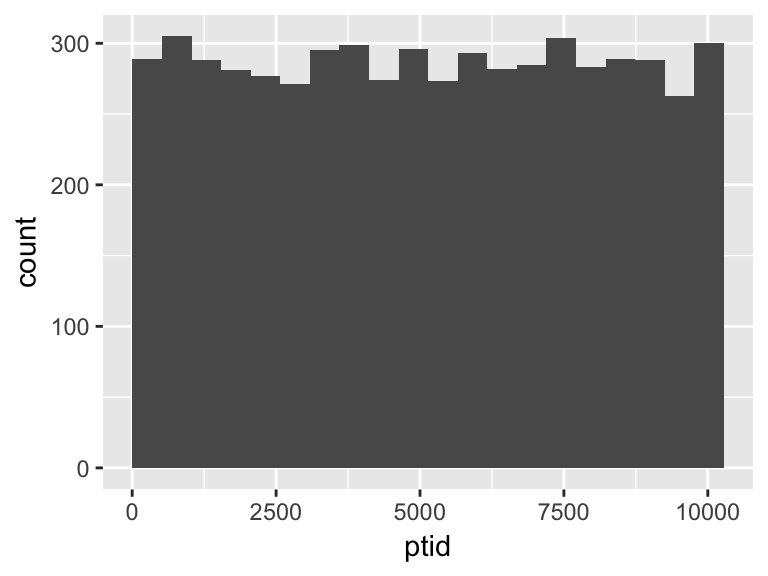

## 8.2 meanbp1

| Feature | Result |
| --- | --- |
| Variable type | numeric |
| Number of missing obs. | 0 (0 %) |
| Number of unique values | 178 |
| Median | 63 |
| 1st and 3rd quartiles | 50; 115 |
| Min. and max. | 0; 259 |

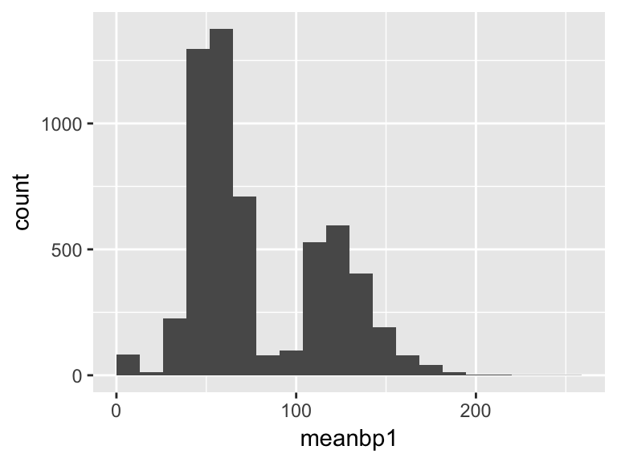

- Note that the following possible outlier values were detected: "0", "10", "13", "15", "17", "18", "20", "21", "24", "25" (13 additional values omitted).

## 8.3 wtkilo1

| Feature | Result |
| --- | --- |
| Variable type | numeric |
| Number of missing obs. | 0 (0 %) |
| Number of unique values | 922 |
| Median | 70 |
| 1st and 3rd quartiles | 56.3; 83.7 |
| Min. and max. | 0; 244 |

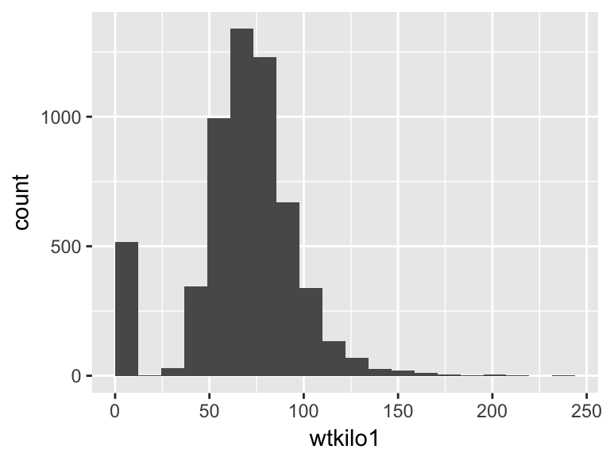

- Note that the following possible outlier values were detected: "0", "120", "120.1", "120.3", "120.4", "120.5", "120.6", "120.8", "120.9", "121" (111 additional values omitted).

## 8.4 cat1

| Feature | Result |
| --- | --- |
| Variable type | character |
| Number of missing obs. | 0 (0 %) |
| Number of unique values | 9 |
| Mode | “ARF” |

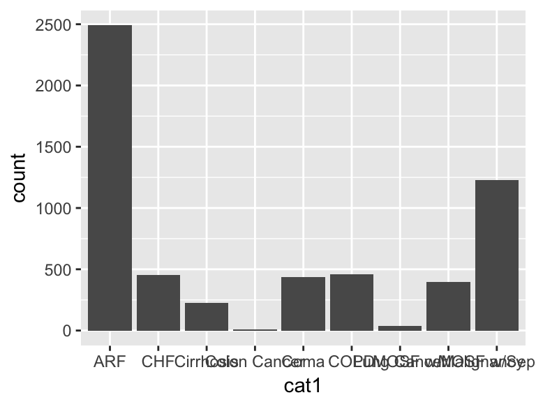

## 8.5 cat2

| Feature | Result |
| --- | --- |
| Variable type | character |
| Number of missing obs. | 4535 (79.08 %) |
| Number of unique values | 6 |
| Mode | “MOSF w/Sepsis” |

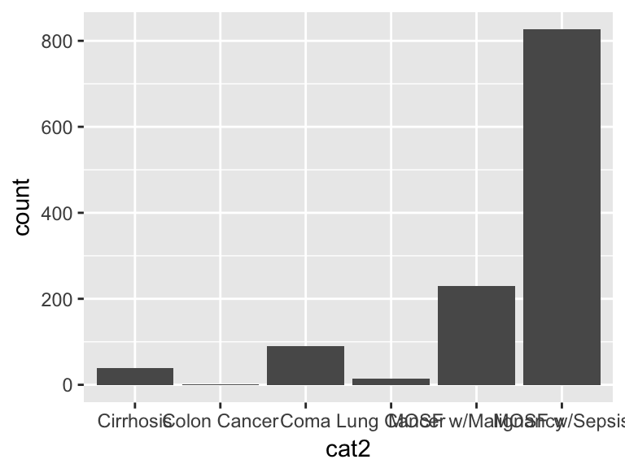

- Note that the following levels have at most five observations: "Colon Cancer".

## 8.6 renalhx

- Note that this variable is treated as a factor variable below, as it only takes a few unique values.

| Feature | Result |
| --- | --- |
| Variable type | integer |
| Number of missing obs. | 0 (0 %) |
| Number of unique values | 2 |
| Mode | “0” |

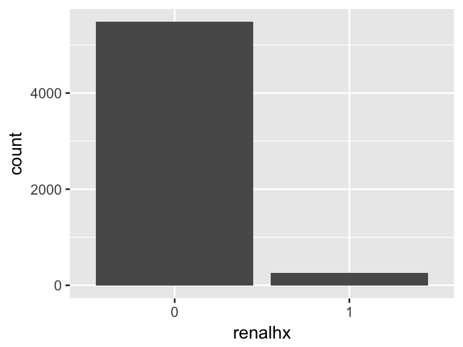

## 8.7 dschdte

| Feature | Result |
| --- | --- |
| Variable type | integer |
| Number of missing obs. | 1 (0.02 %) |
| Number of unique values | 1486 |
| Median | 11777 |
| 1st and 3rd quartiles | 11184; 12120 |
| Min. and max. | 10757; 12560 |

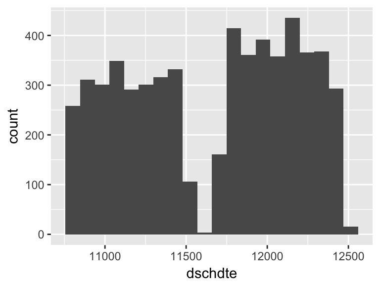

## 8.8 sadmdte

| Feature | Result |
| --- | --- |
| Variable type | integer |
| Number of missing obs. | 0 (0 %) |
| Number of unique values | 1401 |
| Median | 11759 |
| 1st and 3rd quartiles | 11163.5; 12097 |
| Min. and max. | 10754; 12441 |

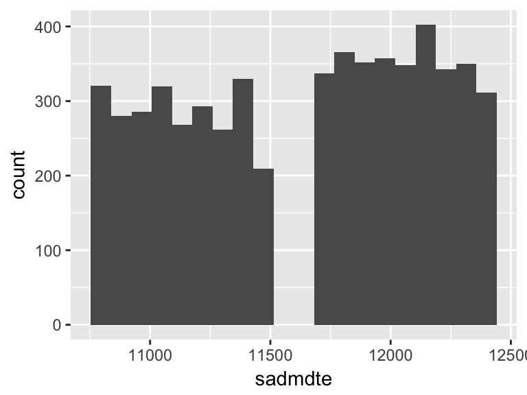

Report generation information:

- Created by Lauren Samuels.
- Report creation time: Fri Dec 01 2017 14:11:24
- dataMaid v1.0.0 [Pkg: 2017-11-10 from CRAN (R 3.4.2)]
- R version 3.4.2 (2017-09-28).
- Platform: x86_64-apple-darwin15.6.0 (64-bit)(macOS Sierra 10.12.6).
- Function call: `dataMaid::makeDataReport(data = rhcdat, output = "html", file = dmReport, replace = TRUE, standAlone = FALSE)`

# 9 dataMaid, continued

## 9.1 Checking what I think should be the primary key— not working as expected

```r
dataMaid::isKey(rhcdat$ptid)
```

```
No problems found.
```

```r
dataMaid::isKey(rhcdat$cat1)
```

```
No problems found.
```

## 9.2 Adding in some problem variables

```r
rhc2 <- within(rhcdat, {
    myKey <- factor(1:nrow(rhcdat))
    mySingular <- 3
    myComplex <- complex(length.out= nrow(rhcdat))
})
```

```r
# You can run this part from an interactive session if you want
if (FALSE) {
    dataMaid::makeDataReport(rhc2,
        output     = "html",
        file       = dmReport2,
        replace    = TRUE,
        standAlone = TRUE,
        render     = TRUE
    )
}
```

# 10 The janitor package

## 10.1 clean_names()

```r
# From their vignette
# Create a data.frame with dirty names
test_df <- as.data.frame(matrix(ncol = 6))
names(test_df) <- c("hIgHlo", "REPEAT VALUE", "REPEAT VALUE",
                    "% successful (2009)",  "abc@!*", "")
print(test_df)
```

```
  hIgHlo REPEAT VALUE REPEAT VALUE % successful (2009) abc@!*
1     NA           NA           NA                  NA     NA NA
```

```r
test_df2 <- test_df %>%
  janitor::clean_names()
print(test_df2)
```

```
  highlo repeat_value repeat_value_2 percent_successful_2009 abc  x
1     NA           NA             NA                      NA  NA NA
```

```r
#Compare to what base R produces:
make.names(names(test_df))
```

```
[1] "hIgHlo"               "REPEAT.VALUE"         "REPEAT.VALUE"         "X..successful..2009." "abc..."               "X"
```

## 10.2 tabyl()

```r
t1 <- table(rhcdat$cat2)
print(t1)
```

```
        Cirrhosis      Colon Cancer              Coma       Lung Cancer MOSF w/Malignancy     MOSF w/Sepsis
               38                 2                90                15               229               826
```

```r
# The next line produces an error
#print(kable(t1))

t2 <- janitor::tabyl(rhcdat$cat2)
# or, equivalently,
t2 <- rhcdat %>% janitor::tabyl(cat2)
print(t2)
```

```
               cat2    n      percent valid_percent
1         Cirrhosis   38 0.0066259808   0.031666667
2      Colon Cancer    2 0.0003487358   0.001666667
3              Coma   90 0.0156931125   0.075000000
4       Lung Cancer   15 0.0026155187   0.012500000
5 MOSF w/Malignancy  229 0.0399302528   0.190833333
6     MOSF w/Sepsis  826 0.1440278989   0.688333333
7              <NA> 4535 0.7907585004            NA
```

```r
print(kable(t2))
```

| cat2 | n | percent | valid_percent |
| --- | --- | --- | --- |
| Cirrhosis | 38 | 0.0066260 | 0.0316667 |
| Colon Cancer | 2 | 0.0003487 | 0.0016667 |
| Coma | 90 | 0.0156931 | 0.0750000 |
| Lung Cancer | 15 | 0.0026155 | 0.0125000 |
| MOSF w/Malignancy | 229 | 0.0399303 | 0.1908333 |
| MOSF w/Sepsis | 826 | 0.1440279 | 0.6883333 |
| NA | 4535 | 0.7907585 | NA |

## 10.3 crosstab()

```r
t3 <- with(rhcdat, table(cat1, cat2))
print(t3)
```

```
                   cat2
cat1                Cirrhosis Colon Cancer Coma Lung Cancer MOSF w/Malignancy MOSF w/Sepsis
  ARF                      38            2   83          13               191           510
  CHF                       0            0    2           0                 0            15
  Cirrhosis                 0            0    0           0                 0            26
  Colon Cancer              0            0    0           0                 2             0
  Coma                      0            0    0           1                19            58
  COPD                      0            0    5           1                11            32
  Lung Cancer               0            0    0           0                 5             0
  MOSF w/Malignancy         0            0    0           0                 0           185
  MOSF w/Sepsis             0            0    0           0                 1             0
```

```r
print(kable(t3))
```

|  | Cirrhosis | Colon Cancer | Coma | Lung Cancer | MOSF w/Malignancy | MOSF w/Sepsis |
| --- | --- | --- | --- | --- | --- | --- |
| ARF | 38 | 2 | 83 | 13 | 191 | 510 |
| CHF | 0 | 0 | 2 | 0 | 0 | 15 |
| Cirrhosis | 0 | 0 | 0 | 0 | 0 | 26 |
| Colon Cancer | 0 | 0 | 0 | 0 | 2 | 0 |
| Coma | 0 | 0 | 0 | 1 | 19 | 58 |
| COPD | 0 | 0 | 5 | 1 | 11 | 32 |
| Lung Cancer | 0 | 0 | 0 | 0 | 5 | 0 |
| MOSF w/Malignancy | 0 | 0 | 0 | 0 | 0 | 185 |
| MOSF w/Sepsis | 0 | 0 | 0 | 0 | 1 | 0 |

```r
t4 <- rhcdat %>% janitor::crosstab(cat1, cat2)
print(t4)
```

```
               cat1 Cirrhosis Colon Cancer Coma Lung Cancer MOSF w/Malignancy MOSF w/Sepsis  NA_
1               ARF        38            2   83          13               191           510 1653
2               CHF         0            0    2           0                 0            15  439
3         Cirrhosis         0            0    0           0                 0            26  198
4      Colon Cancer         0            0    0           0                 2             0    5
5              Coma         0            0    0           1                19            58  358
6              COPD         0            0    5           1                11            32  408
7       Lung Cancer         0            0    0           0                 5             0   34
8 MOSF w/Malignancy         0            0    0           0                 0           185  214
9     MOSF w/Sepsis         0            0    0           0                 1             0 1226
```

```r
print(kable(t4))
```

| cat1 | Cirrhosis | Colon Cancer | Coma | Lung Cancer | MOSF w/Malignancy | MOSF w/Sepsis | NA_ |
| --- | --- | --- | --- | --- | --- | --- | --- |
| ARF | 38 | 2 | 83 | 13 | 191 | 510 | 1653 |
| CHF | 0 | 0 | 2 | 0 | 0 | 15 | 439 |
| Cirrhosis | 0 | 0 | 0 | 0 | 0 | 26 | 198 |
| Colon Cancer | 0 | 0 | 0 | 0 | 2 | 0 | 5 |
| Coma | 0 | 0 | 0 | 1 | 19 | 58 | 358 |
| COPD | 0 | 0 | 5 | 1 | 11 | 32 | 408 |
| Lung Cancer | 0 | 0 | 0 | 0 | 5 | 0 | 34 |
| MOSF w/Malignancy | 0 | 0 | 0 | 0 | 0 | 185 | 214 |
| MOSF w/Sepsis | 0 | 0 | 0 | 0 | 1 | 0 | 1226 |

## 10.4 adorn_crosstab() and adorn_totals()

```r
t5 <-  t4 %>%
    janitor::adorn_crosstab()

print(t5)
```

```
               cat1 Cirrhosis Colon Cancer      Coma Lung Cancer MOSF w/Malignancy MOSF w/Sepsis          NA_
1               ARF 1.5% (38)     0.1% (2) 3.3% (83)   0.5% (13)        7.7% (191)   20.5% (510) 66.4% (1653)
2               CHF 0.0%  (0)     0.0% (0) 0.4%  (2)   0.0%  (0)        0.0%   (0)    3.3%  (15) 96.3%  (439)
3         Cirrhosis 0.0%  (0)     0.0% (0) 0.0%  (0)   0.0%  (0)        0.0%   (0)   11.6%  (26) 88.4%  (198)
4      Colon Cancer 0.0%  (0)     0.0% (0) 0.0%  (0)   0.0%  (0)       28.6%   (2)    0.0%   (0) 71.4%    (5)
5              Coma 0.0%  (0)     0.0% (0) 0.0%  (0)   0.2%  (1)        4.4%  (19)   13.3%  (58) 82.1%  (358)
6              COPD 0.0%  (0)     0.0% (0) 1.1%  (5)   0.2%  (1)        2.4%  (11)    7.0%  (32) 89.3%  (408)
7       Lung Cancer 0.0%  (0)     0.0% (0) 0.0%  (0)   0.0%  (0)       12.8%   (5)    0.0%   (0) 87.2%   (34)
8 MOSF w/Malignancy 0.0%  (0)     0.0% (0) 0.0%  (0)   0.0%  (0)        0.0%   (0)   46.4% (185) 53.6%  (214)
9     MOSF w/Sepsis 0.0%  (0)     0.0% (0) 0.0%  (0)   0.0%  (0)        0.1%   (1)    0.0%   (0) 99.9% (1226)
```

```r
print(kable(t5))
```

| cat1 | Cirrhosis | Colon Cancer | Coma | Lung Cancer | MOSF w/Malignancy | MOSF w/Sepsis | NA_ |
| --- | --- | --- | --- | --- | --- | --- | --- |
| ARF | 1.5% (38) | 0.1% (2) | 3.3% (83) | 0.5% (13) | 7.7% (191) | 20.5% (510) | 66.4% (1653) |
| CHF | 0.0% (0) | 0.0% (0) | 0.4% (2) | 0.0% (0) | 0.0% (0) | 3.3% (15) | 96.3% (439) |
| Cirrhosis | 0.0% (0) | 0.0% (0) | 0.0% (0) | 0.0% (0) | 0.0% (0) | 11.6% (26) | 88.4% (198) |
| Colon Cancer | 0.0% (0) | 0.0% (0) | 0.0% (0) | 0.0% (0) | 28.6% (2) | 0.0% (0) | 71.4% (5) |
| Coma | 0.0% (0) | 0.0% (0) | 0.0% (0) | 0.2% (1) | 4.4% (19) | 13.3% (58) | 82.1% (358) |
| COPD | 0.0% (0) | 0.0% (0) | 1.1% (5) | 0.2% (1) | 2.4% (11) | 7.0% (32) | 89.3% (408) |
| Lung Cancer | 0.0% (0) | 0.0% (0) | 0.0% (0) | 0.0% (0) | 12.8% (5) | 0.0% (0) | 87.2% (34) |
| MOSF w/Malignancy | 0.0% (0) | 0.0% (0) | 0.0% (0) | 0.0% (0) | 0.0% (0) | 46.4% (185) | 53.6% (214) |
| MOSF w/Sepsis | 0.0% (0) | 0.0% (0) | 0.0% (0) | 0.0% (0) | 0.1% (1) | 0.0% (0) | 99.9% (1226) |

```r
t6 <-  t4 %>%
    janitor::adorn_crosstab(show_totals= TRUE)
print(kable(t6))
```

| cat1 | Cirrhosis | Colon Cancer | Coma | Lung Cancer | MOSF w/Malignancy | MOSF w/Sepsis | NA_ |
| --- | --- | --- | --- | --- | --- | --- | --- |
| ARF | 1.5% (38) | 0.1% (2) | 3.3% (83) | 0.5% (13) | 7.7% (191) | 20.5% (510) | 66.4% (1653) |
| CHF | 0.0% (0) | 0.0% (0) | 0.4% (2) | 0.0% (0) | 0.0% (0) | 3.3% (15) | 96.3% (439) |
| Cirrhosis | 0.0% (0) | 0.0% (0) | 0.0% (0) | 0.0% (0) | 0.0% (0) | 11.6% (26) | 88.4% (198) |
| Colon Cancer | 0.0% (0) | 0.0% (0) | 0.0% (0) | 0.0% (0) | 28.6% (2) | 0.0% (0) | 71.4% (5) |
| Coma | 0.0% (0) | 0.0% (0) | 0.0% (0) | 0.2% (1) | 4.4% (19) | 13.3% (58) | 82.1% (358) |
| COPD | 0.0% (0) | 0.0% (0) | 1.1% (5) | 0.2% (1) | 2.4% (11) | 7.0% (32) | 89.3% (408) |
| Lung Cancer | 0.0% (0) | 0.0% (0) | 0.0% (0) | 0.0% (0) | 12.8% (5) | 0.0% (0) | 87.2% (34) |
| MOSF w/Malignancy | 0.0% (0) | 0.0% (0) | 0.0% (0) | 0.0% (0) | 0.0% (0) | 46.4% (185) | 53.6% (214) |
| MOSF w/Sepsis | 0.0% (0) | 0.0% (0) | 0.0% (0) | 0.0% (0) | 0.1% (1) | 0.0% (0) | 99.9% (1226) |
| Total | 0.7% (38) | 0.0% (2) | 1.6% (90) | 0.3% (15) | 4.0% (229) | 14.4% (826) | 79.1% (4535) |

```r
t7 <- t4 %>%
    janitor::adorn_totals()
print(kable(t7))
```

| cat1 | Cirrhosis | Colon Cancer | Coma | Lung Cancer | MOSF w/Malignancy | MOSF w/Sepsis | NA_ | Total |
| --- | --- | --- | --- | --- | --- | --- | --- | --- |
| ARF | 38 | 2 | 83 | 13 | 191 | 510 | 1653 | 2490 |
| CHF | 0 | 0 | 2 | 0 | 0 | 15 | 439 | 456 |
| Cirrhosis | 0 | 0 | 0 | 0 | 0 | 26 | 198 | 224 |
| Colon Cancer | 0 | 0 | 0 | 0 | 2 | 0 | 5 | 7 |
| Coma | 0 | 0 | 0 | 1 | 19 | 58 | 358 | 436 |
| COPD | 0 | 0 | 5 | 1 | 11 | 32 | 408 | 457 |
| Lung Cancer | 0 | 0 | 0 | 0 | 5 | 0 | 34 | 39 |
| MOSF w/Malignancy | 0 | 0 | 0 | 0 | 0 | 185 | 214 | 399 |
| MOSF w/Sepsis | 0 | 0 | 0 | 0 | 1 | 0 | 1226 | 1227 |
| Total | 38 | 2 | 90 | 15 | 229 | 826 | 4535 | 5735 |

## 10.5 get_dupes()

```r
mydups <- rhcdat %>% janitor::get_dupes(ptid)
print(mydups)
```

```
# A tibble: 0 x 9
# ... with 9 variables: ptid <int>, dupe_count <int>, meanbp1 <dbl>, wtkilo1 <dbl>, cat1 <chr>, cat2 <chr>, renalhx <int>, dschdte <int>, sadmdte <int>
```

```r
# add in a row with a duplicate id
rhc3 <- rbind(rhcdat[1, ], rhcdat)
mydups2 <- rhc3 %>% janitor::get_dupes(ptid)
print(kable(mydups2))
```

| ptid | dupe_count | meanbp1 | wtkilo1 | cat1 | cat2 | renalhx | dschdte | sadmdte |
| --- | --- | --- | --- | --- | --- | --- | --- | --- |
| 5 | 2 | 41 | 64.69995 | COPD | NA | 0 | 11151 | 11142 |
| 5 | 2 | 41 | 64.69995 | COPD | NA | 0 | 11151 | 11142 |

```r
# View(mydups2)
```

# 11 The validate package

```r
valSum <- validate::check_that(rhcdat,
    meanbp1 > 0,
    wtkilo1 > 0,
    is.na(dschdte) | dschdte >= sadmdte
)
print(summary(valSum))
```

```
  name items passes fails nNA error warning                          expression
1   V1  5735   5655    80   0 FALSE   FALSE                         meanbp1 > 0
2   V2  5735   5220   515   0 FALSE   FALSE                         wtkilo1 > 0
3   V3  5735   5735     0   0 FALSE   FALSE is.na(dschdte) | dschdte >= sadmdte
```

```r
print(kable(summary(valSum)))
```

| name | items | passes | fails | nNA | error | warning | expression |
| --- | --- | --- | --- | --- | --- | --- | --- |
| V1 | 5735 | 5655 | 80 | 0 | FALSE | FALSE | meanbp1 > 0 |
| V2 | 5735 | 5220 | 515 | 0 | FALSE | FALSE | wtkilo1 > 0 |
| V3 | 5735 | 5735 | 0 | 0 | FALSE | FALSE | is.na(dschdte) \| dschdte >= sadmdte |

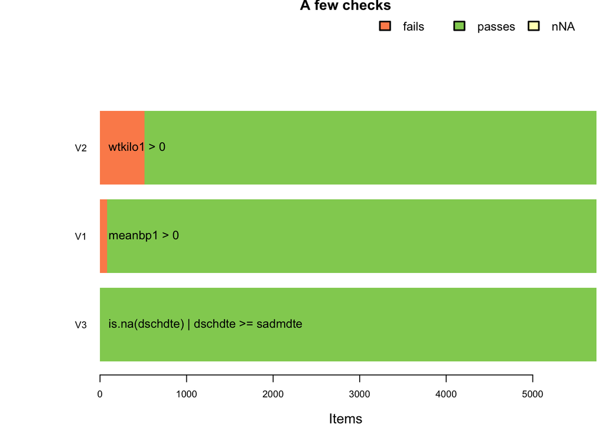

```r
barplot(valSum, main= "A few checks")
```

```r
v <- validate::validator(
    meanbp1 > 0,
    wtkilo1 > 0,
    is.na(dschdte) | dschdte >= sadmdte
)
print(v)
```

```
Object of class 'validator' with 3 elements:
 V1: meanbp1 > 0
 V2: wtkilo1 > 0
 V3: is.na(dschdte) | dschdte >= sadmdte
```

```r
cf <- confront(rhcdat, v)

print(cf)
```

```
Object of class 'validation'
Call:
    confront(x = rhcdat, dat = v)

Confrontations: 3
With fails    : 2
Warnings      : 0
Errors        : 0
```

```r
print(summary(cf))
```

```
  name items passes fails nNA error warning                          expression
1   V1  5735   5655    80   0 FALSE   FALSE                         meanbp1 > 0
2   V2  5735   5220   515   0 FALSE   FALSE                         wtkilo1 > 0
3   V3  5735   5735     0   0 FALSE   FALSE is.na(dschdte) | dschdte >= sadmdte
```

```r
print(aggregate(cf) )
```

```
   npass nfail nNA  rel.pass   rel.fail rel.NA
V1  5655    80   0 0.9860506 0.01394943      0
V2  5220   515   0 0.9102005 0.08979948      0
V3  5735     0   0 1.0000000 0.00000000      0
```

```r
print(head(aggregate(cf,by='record')))
```

```
  npass nfail nNA  rel.pass  rel.fail rel.NA
1     3     0   0 1.0000000 0.0000000      0
2     3     0   0 1.0000000 0.0000000      0
3     2     1   0 0.6666667 0.3333333      0
4     3     0   0 1.0000000 0.0000000      0
5     3     0   0 1.0000000 0.0000000      0
6     3     0   0 1.0000000 0.0000000      0
```

```r
print(kable(summary(cf)))
```

| name | items | passes | fails | nNA | error | warning | expression |
| --- | --- | --- | --- | --- | --- | --- | --- |
| V1 | 5735 | 5655 | 80 | 0 | FALSE | FALSE | meanbp1 > 0 |
| V2 | 5735 | 5220 | 515 | 0 | FALSE | FALSE | wtkilo1 > 0 |
| V3 | 5735 | 5735 | 0 | 0 | FALSE | FALSE | is.na(dschdte) \| dschdte >= sadmdte |

```r
valdat <- data.frame(values(cf))
print(kable(head(valdat)))
```

| V1 | V2 | V3 |
| --- | --- | --- |
| TRUE | TRUE | TRUE |
| TRUE | TRUE | TRUE |
| TRUE | FALSE | TRUE |
| TRUE | TRUE | TRUE |
| TRUE | TRUE | TRUE |
| TRUE | TRUE | TRUE |

```r
valdat <- cbind(ptid= rhcdat$ptid, valdat)
print(kable(head(valdat)))
```

| ptid | V1 | V2 | V3 |
| --- | --- | --- | --- |
| 5 | TRUE | TRUE | TRUE |
| 7 | TRUE | TRUE | TRUE |
| 9 | TRUE | FALSE | TRUE |
| 10 | TRUE | TRUE | TRUE |
| 11 | TRUE | TRUE | TRUE |
| 12 | TRUE | TRUE | TRUE |

```r
valdat2 <- valdat[with(valdat, !(V1 & V2 & V3)), ]
print(kable(head(valdat2), row.names= FALSE))
```

| ptid | V1 | V2 | V3 |
| --- | --- | --- | --- |
| 9 | TRUE | FALSE | TRUE |
| 13 | TRUE | FALSE | TRUE |
| 29 | TRUE | FALSE | TRUE |
| 83 | TRUE | FALSE | TRUE |
| 101 | TRUE | FALSE | TRUE |
| 132 | TRUE | FALSE | TRUE |

```r
print(v)
```

```
Object of class 'validator' with 3 elements:
 V1: meanbp1 > 0
 V2: wtkilo1 > 0
 V3: is.na(dschdte) | dschdte >= sadmdte
```

```r
vdf <- as.data.frame(v)
rulevec <- vdf$rule
print(rulevec)
```

```
[1] "meanbp1 > 0"                         "wtkilo1 > 0"                         "is.na(dschdte) | dschdte >= sadmdte"
```

```r
ruledat <- data.frame(t(
    apply(valdat2[, 2:ncol(valdat2)], 1, function(vec) {
    cbind(ifelse(vec == "FALSE", "X", ""))
})))
names(ruledat) <- rulevec
ruledat <- cbind(ptid= valdat2$ptid, ruledat)
print(kable(head(ruledat), row.names= FALSE))
```

| ptid | meanbp1 > 0 | wtkilo1 > 0 | is.na(dschdte) \| dschdte >= sadmdte |
| --- | --- | --- | --- |
| 9 |  | X |  |
| 13 |  | X |  |
| 29 |  | X |  |
| 83 |  | X |  |
| 101 |  | X |  |
| 132 |  | X |  |

# 12 The assertr package— we didn’t get to this; note I have set all chunks to eval= FALSE

## 12.1 verify()

```r
d1 <- rhcdat %>%
  assertr::verify(meanbp1 > 0) %>%
  group_by(cat1) %>%
  summarise(avg.meanbp1 = mean(meanbp1))
d1

assertr::verify(rhcdat, meanbp1 > 0)
```

“The verify function takes a data frame (its first argument is provided by the %>% operator), and a logical (boolean) expression. Then, verify evaluates that expression using the scope of the provided data frame. If any of the logical values of the expression’s result are FALSE, verify will raise an error that terminates any further processing of the pipeline.”

## 12.2 assert()

“The assert function takes a data frame, a predicate function, and an arbitrary number of columns to apply the predicate function to. The predicate function (a function that returns a logical/boolean value) is then applied to every element of the columns selected, and will raise an error when if it finds violations.”

```r
d2 <- assertr::assert(rhcdat, within_bounds(0, Inf, include.lower= FALSE, include.upper= TRUE, allow.na= TRUE), meanbp1) %>%
  group_by(cat1) %>%
  summarise(avg.meanbp1 = mean(meanbp1))

d2
```

```r
d3 <- rhcdat %>%
    assertr::assert(within_bounds(0, Inf, include.lower= FALSE, include.upper= TRUE, allow.na= TRUE),
        meanbp1,
        error_fun= error_append)

d3
str(d3)
e1 <- attr(d3, "assertr_errors")
e1df <- e1[[1]]$error_df
```

```r
d4 <- rhcdat %>%
    assertr::assert(within_bounds(0, Inf, include.lower= FALSE, include.upper= TRUE, allow.na= TRUE),
        meanbp1,
        error_fun= error_append) %>%
    assertr::assert(not_na,
        dschdte,
        error_fun= error_append)

d4
str(d4)
e2 <- attr(d4, "assertr_errors")
e2df1 <- e2[[1]]$error_df
e2df2 <- e2[[2]]$error_df
```

To cite R in publication use:

R Core Team (2017). *R: A Language and Environment for Statistical Computing*. R Foundation for Statistical Computing, Vienna, Austria. https://www.R-project.org/.